# Bayesian Regression Models with RStanARM

TJ Mahr  
Sept. 21, 2016

Madison R Users Group

[Github repository](https://github.com/tjmahr/MadR_RStanARM)  
[@tjmahr](https://twitter.com/tjmahr)

### Overview

- **[How I got into Bayesian statistics](http://rpubs.com/tjmahr/rep-crisis)**
- [Some intuition-building about Bayes theorem](http://rpubs.com/tjmahr/bayes-theorem)
- [Tour of RStanARM](http://rpubs.com/tjmahr/rstanarm-tour)
- [Where to learn more about Bayesian statistics](http://rpubs.com/tjmahr/bayes-learn-more)

### August 2015: The "Crisis" in Psychology

[Open Science Collaboration (2015)](http://science.sciencemag.org/content/349/6251/aac4716) tries to replicate 100 studies published in 3 psychology different journals in 2008.

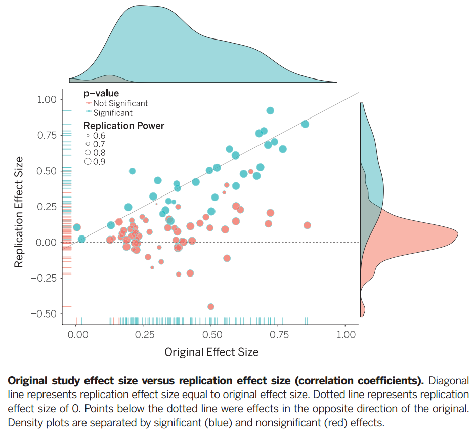

- Boil a study down to 1 test statistic and 1 effect size.
  - Compare replication's test and effect size against original.
- Approximately 36% of the studies are replicated (same test statistic.
- On average, effect sizes in replications are half that of the original studies.

### Reactions

We're doomed.

[figure not shown]

Most findings are probably false.

No, this is business as usual.

[figure not shown]

Any credible discipline has to do this kind of house-cleaning from time to time.

### Lots of hand-wringing and soul-searching

Some reactionary:

- Replication creates an [industry for incompetent hacks](http://www.sciencedirect.com/science/article/pii/S002210311600007X).
- Here come the [methodological terrorists](http://andrewgelman.com/2016/09/21/what-has-happened-down-here-is-the-winds-have-changed/)!

[figure not shown]

Some constructive:

- [Everything is f'ed](https://hardsci.wordpress.com/2016/08/11/everything-is-fucked-the-syllabus/) – so what else is new?
- Increased rigor and openness are [a good thing](https://thenib.com/repeat-after-me).

### I'm in the business-as-usual camp, by the way

Better research practices are catching on.

- Pre-registration
- Power analyses and [other foresight](http://www.johndcook.com/blog/2010/05/13/statistical-autopsy/).
- Meta-analytic tools to assess the health of a field
- Better disclosure of other unanalyzed measurements

### Crisis made me think more of questionable data analysis practices

Basically, unintentional acts and rituals to appease Statistical Significance gods.

- HARKing (hypothesizing after results are known)
  - Telling a story to fit the data.
- Garden of forking data
  - Conducting countless sub-tests and sub-analyses on the data
- p-hacking
  - Doing these tests in order to find a significant effect.
- Selective reporting
  - Reporting only the tests that yielded a significant result.

### My response to the crisis

I want to avoid these errors.

- I want to level up my stats and explore new techniques.
  - Maybe more robust estimation techniques
  - Maybe machine learning techniques to complement conventional analyses.
- I want something less finicky than statistical significance.
  - p-values don't mean what many people think they mean.
  - Neither do confidence intervals.
  - Statistical significance is not related to practical significance.

### December 2015

- I started reading the Gelman and Hill book.
  - This is the book for [the `arm` package](https://cran.rstudio.com/web/packages/arm/).
- It emphasizes estimation, uncertainty and simulation.
- Midway through, the book pivots to Bayesian estimation.
- I roll with it.

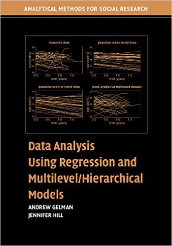

I try to download the example BUGS scripts, but they are no longer supported.

Instead, I find [a page with the title](http://www.stat.columbia.edu/%7Egelman/bugsR/):

### Use Stan instead.

Okay, I'll give it try…

### January 2016

I'm down a rabbit hole, writing Stan models to fit the models from the ARM book, and there is an influx of Bayesian tools for R.

- [Statistical Rethinking](http://xcelab.net/rm/statistical-rethinking/), a book that reteaches regression from a Bayesian perspective with R and Stan, is released.
- New version of [brms](https://cran.r-project.org/web/packages/brms/index.html) is released. This package converts R model code into Stan programs.
- [RStanARM](https://cran.r-project.org/web/packages/rstanarm/index.html) is released.
- This blog post circulates: [“R Users Will Now Inevitably Become Bayesians”](https://thinkinator.com/2016/01/12/r-users-will-now-inevitably-become-bayesians/).

I eat all this up. I become a convert.

### Long story short

The replication crisis sparked my curiosity, and a wave of new tools and resources made it really easy to get started with Bayesian stats.

No formal coursework. I learned about the math/statistics from playing with code.

My goal with these toosl has been to make better, more honest scientific summaries of observed data.

### Next

- [How I got into Bayesian statistics](http://rpubs.com/tjmahr/rep-crisis)
- **[Some intuition-building about Bayes theorem](http://rpubs.com/tjmahr/bayes-theorem)**
- [Tour of RStanARM](http://rpubs.com/tjmahr/rstanarm-tour)
- [Where to learn more about Bayesian statistics](http://rpubs.com/tjmahr/bayes-learn-more)